# STA6246 - DOE

ANOVA Examples

Author

Dr. Cohen

## Etching Process Experiment

The goal of this experiment is to compare 4 Radio Frequency (RF) power to obtain the desired etching rate.

### Data description

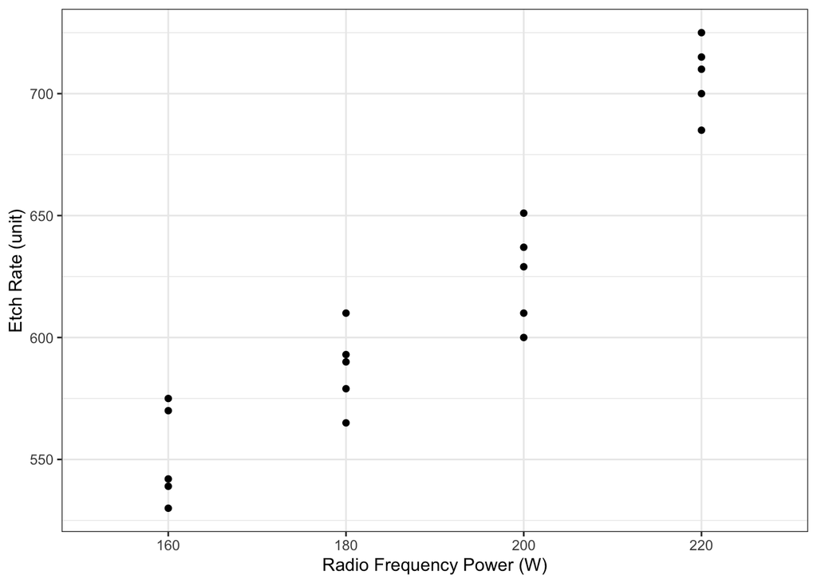

```r
library(tidyverse)
library(gtsummary)
# enter ER
Etch_Rate=c(575,542,530,539,570,565,593,590,579,610,600,651,610,637,629,725,700,715,685,710)
# enter RF
RF=gl(n = 4, k = 5, labels = c("160","180","200","220"))
# put together data in a tibble
etch_exp=tibble(Etch_Rate,RF)

etch_exp %>%
  ggplot(aes(x=RF,y=Etch_Rate)) +
  geom_point()+
  theme_bw()+
  labs(x="Radio Frequency Power (W)",
       y="Etch Rate (unit)")
```

```r
etch_exp %>%
  tbl_summary(by=RF)
```

| **Characteristic** | **160**, N = 5<sup>1</sup> | **180**, N = 5<sup>1</sup> | **200**, N = 5<sup>1</sup> | **220**, N = 5<sup>1</sup> |
| --- | --- | --- | --- | --- |
| Etch_Rate | 542 (539, 570) | 590 (579, 593) | 629 (610, 637) | 710 (700, 715) |

<sup>1</sup> Median (IQR)

- The etching rate seems to increase with the RF power.
- The variability seems to be similar among the groups (powers)

### ANOVA in R

##### Fitting

```r
library(sjPlot)

# ANOVA one factor
results = aov(Etch_Rate ~ RF,data = etch_exp)
summary(results)
```

```
            Df Sum Sq Mean Sq F value   Pr(>F)
RF           3  66871   22290    66.8 2.88e-09 ***
Residuals   16   5339     334
---
Signif. codes:  0 '***' 0.001 '**' 0.01 '*' 0.05 '.' 0.1 ' ' 1
```

```r
tab_model(results)
```

|  | Etch_Rate |
| --- | --- |
| Predictors | p |
| RF | **<0.001** |
| Residuals |  |
| Observations | 20 |
| R<sup>2</sup> / R<sup>2</sup> adjusted | 0.926 / 0.912 |

```r
# Individual CIs - need to add the CI for the reference level
confint(results)
```

```
                2.5 %    97.5 %
(Intercept) 533.88153 568.51847
RF180        11.70798  60.69202
RF200        49.70798  98.69202
RF220       131.30798 180.29202
```

The ANOVA was rejected (p-value $< 0.001$). Therefore, the data is compatible with the means difference in the population. Next, we will diagnose the model.

##### Model Adequacy

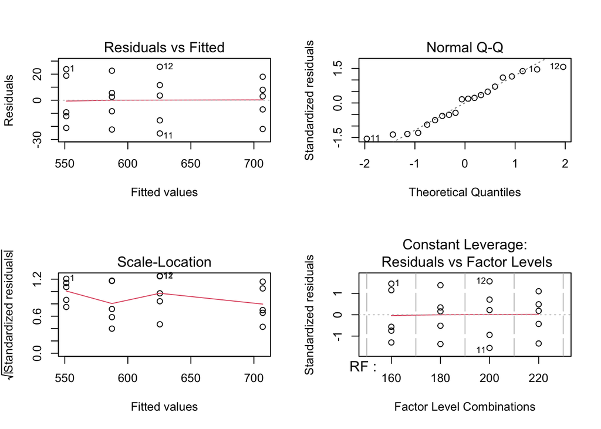

```r
par(mfrow=c(2,2))
plot(results)
```

The residuals plots do not show any major departures from the ANOVA assumptions.

##### Multiple Comparison

Considering 5% level of significance.

```r
# Multiple Comparison
pairwise.t.test(Etch_Rate,RF,p.adjust.method = "bonferroni")
```

```
    Pairwise comparisons using t tests with pooled SD

data:  Etch_Rate and RF

    160     180     200
180 0.038   -       -
200 5.1e-05 0.028   -
220 2.2e-09 1.0e-07 1.6e-05

P value adjustment method: bonferroni
```

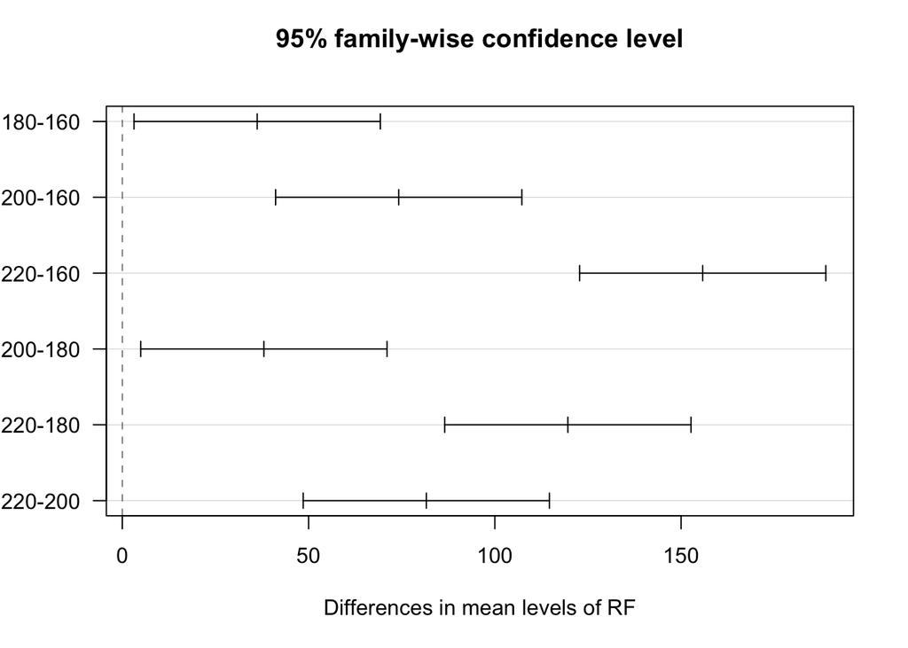

```r
#Tukey Test
THSD=TukeyHSD(results)
plot(THSD,las=1)
```

```r
# Fisher LSD Test
library(agricolae)
L=LSD.test(results,"RF",console=TRUE,group = F)
```

```
Study: results ~ "RF"

LSD t Test for Etch_Rate

Mean Square Error:  333.7

RF,  means and individual ( 95 %) CI

    Etch_Rate      std r      LCL      UCL Min Max
160     551.2 20.01749 5 533.8815 568.5185 530 575
180     587.4 16.74216 5 570.0815 604.7185 565 610
200     625.4 20.52559 5 608.0815 642.7185 600 651
220     707.0 15.24795 5 689.6815 724.3185 685 725

Alpha: 0.05 ; DF Error: 16
Critical Value of t: 2.119905

Comparison between treatments means

          difference pvalue signif.        LCL        UCL
160 - 180      -36.2 0.0064      **  -60.69202  -11.70798
160 - 200      -74.2 0.0000     ***  -98.69202  -49.70798
160 - 220     -155.8 0.0000     *** -180.29202 -131.30798
180 - 200      -38.0 0.0046      **  -62.49202  -13.50798
180 - 220     -119.6 0.0000     *** -144.09202  -95.10798
200 - 220      -81.6 0.0000     *** -106.09202  -57.10798
```

**Conclusion**:

The Radio Frequency Power setting does affect the etching rate in the etching process. The higher the RF power the higher the etch rate.

## Peak Discharge Data

An Engineer is interested in determining whether **4 different methods** of estimating flood flow frequency produce equivalent estimates of **peak discharge** when applied to the same watershed. **Six** replications were run. Therefore. we have 6*4= **24 runs.**

```r
pd=c(0.34,0.12,1.23,0.7,1.75,0.12,0.91,2.94,2.14,2.36,2.86,4.55,6.31,8.37,9.75,6.09,9.82,7.24,17.15,11.82,10.95,17.20,14.35,16.82)

methods=gl(n = 4, k = 6, length = 24, labels = c("a","b","c","d"))

peak_discharge_exp = tibble(pd,methods)
```

### Data description

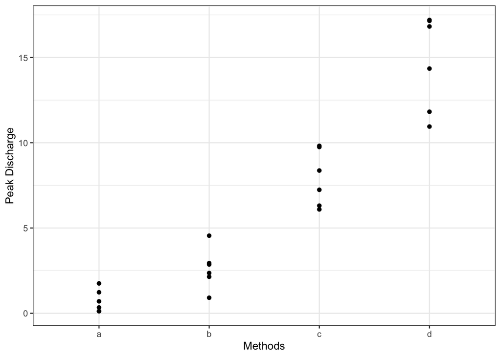

```r
peak_discharge_exp %>%
  ggplot(aes(x=methods,y=pd)) +
  geom_point()+
  theme_bw()+
  labs(x="Methods",
       y="Peak Discharge")
```

```r
peak_discharge_exp %>%
  tbl_summary(by=methods,
              statistic = list(pd ~ "{mean} ({sd}); [{min}, {max}]") )
```

| **Characteristic** | **a**, N = 6<sup>1</sup> | **b**, N = 6<sup>1</sup> | **c**, N = 6<sup>1</sup> | **d**, N = 6<sup>1</sup> |
| --- | --- | --- | --- | --- |
| pd | 0.7 (0.7); [0.1, 1.8] | 2.6 (1.2); [0.9, 4.6] | 7.9 (1.6); [6.1, 9.8] | 14.7 (2.8); [11.0, 17.2] |

<sup>1</sup> Mean (SD); [Range]

### ANOVA in R

##### Fitting

```r
library(sjPlot)

# ANOVA one factor
results = aov(pd ~ methods,data = peak_discharge_exp)
summary(results)
```

```
            Df Sum Sq Mean Sq F value   Pr(>F)
methods      3  708.3   236.1   76.07 4.11e-11 ***
Residuals   20   62.1     3.1
---
Signif. codes:  0 '***' 0.001 '**' 0.01 '*' 0.05 '.' 0.1 ' ' 1
```

```r
tab_model(results)
```

|  | pd |
| --- | --- |
| Predictors | p |
| methods | **<0.001** |
| Residuals |  |
| Observations | 24 |
| R<sup>2</sup> / R<sup>2</sup> adjusted | 0.919 / 0.907 |

```r
# Individual CIs - need to add the CI for the reference level
confint(results)
```

```
                 2.5 %    97.5 %
(Intercept) -0.7903608  2.210361
methodsb    -0.2051640  4.038497
methodsc     5.0981694  9.341831
methodsd    11.8831694 16.126831
```

The ANOVA was rejected (p-value $< 0.001$). Therefore, the data is compatible with the means difference in the population. Next, we will diagnose the model.

##### Model Adequacy

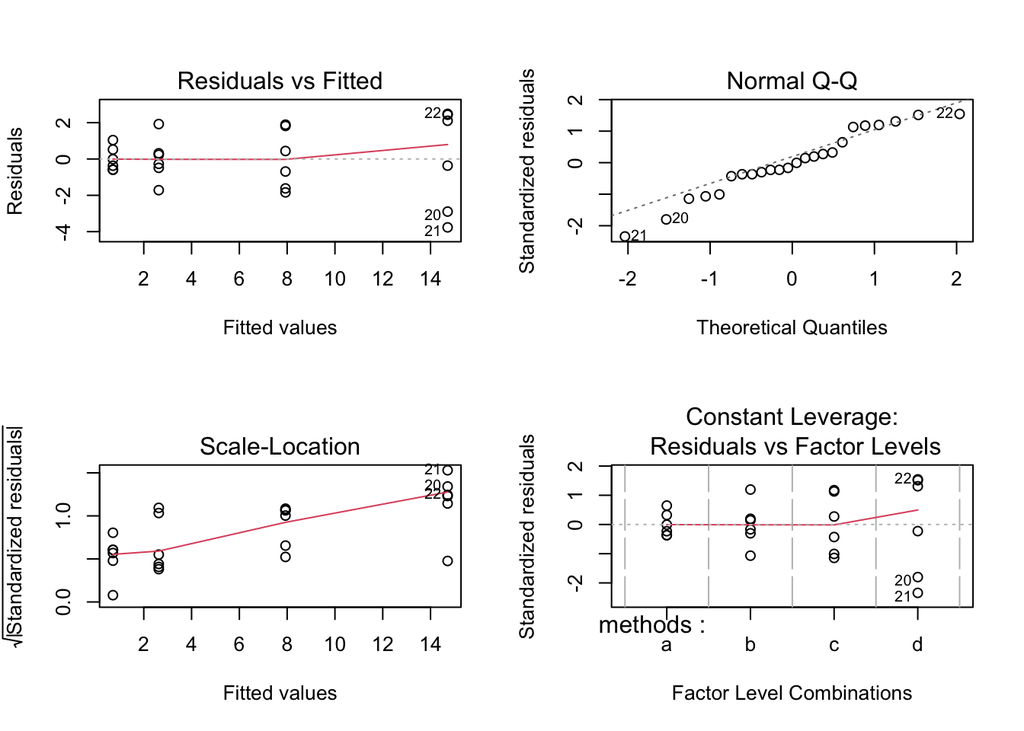

```r
par(mfrow=c(2,2))
plot(results)
```

The residuals plots do not show any major departures from the ANOVA assumptions, except the variance constant assumption.

##### Cox-Box Transformation for stabilizing variance

```r
library(car)
PT=powerTransform(results)

peak_discharge_exp = peak_discharge_exp %>%
  mutate(pdT= 2*(sqrt(pd)-1))


# ANOVA one factor
resultsT = aov(pdT ~ methods,data = peak_discharge_exp)
summary(resultsT)
```

```
            Df Sum Sq Mean Sq F value  Pr(>F)
methods      3 130.74   43.58   81.05 2.3e-11 ***
Residuals   20  10.75    0.54
---
Signif. codes:  0 '***' 0.001 '**' 0.01 '*' 0.05 '.' 0.1 ' ' 1
```

```r
tab_model(resultsT,results)
```

|  | pdT | pd |
| --- | --- | --- |
| Predictors | p | p |
| methods | **<0.001** | **<0.001** |
| Residuals |  |  |
| Observations | 24 | 24 |
| R<sup>2</sup> / R<sup>2</sup> adjusted | 0.924 / 0.913 | 0.919 / 0.907 |

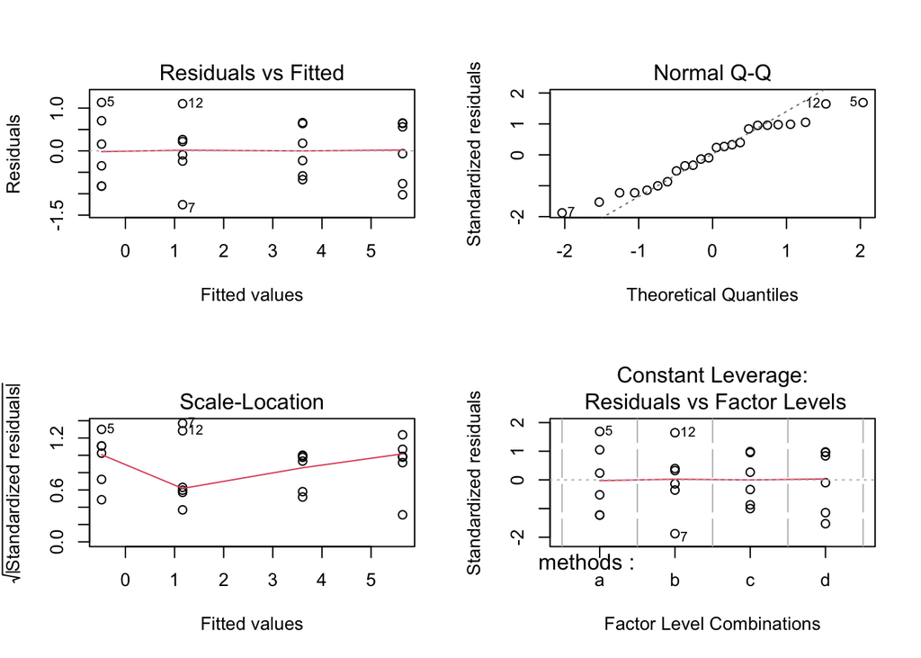

```r
# residuals plots
par(mfrow=c(2,2))
plot(resultsT)
```

The p-value <0.001 so the ANOVA null hypothesis is rejected. Data supports evidence of peak discharge mean difference among the methods.

##### Multiple Comparison

Considering 5% level of significance.

```r
# Multiple Comparison
pairwise.t.test(pd,methods,p.adjust.method = "bonferroni")
```

```
    Pairwise comparisons using t tests with pooled SD

data:  pd and methods

  a       b       c
b 0.44489 -       -
c 4.2e-06 0.00025 -
d 6.9e-11 9.7e-10 1.0e-05

P value adjustment method: bonferroni
```

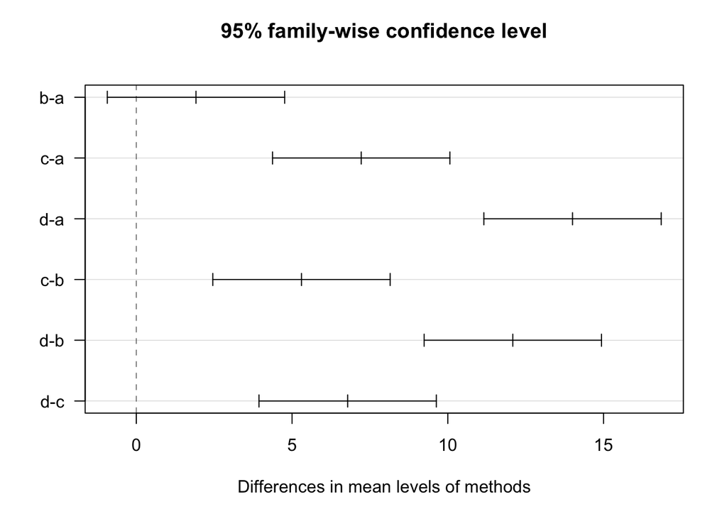

```r
#Tukey Test
THSD=TukeyHSD(results)
plot(THSD,las=1)
```

```r
# Fisher LSD Test
library(agricolae)
L=LSD.test(results,"methods",console=TRUE,group = F)
```

```
Study: results ~ "methods"

LSD t Test for pd

Mean Square Error:  3.104054

methods,  means and individual ( 95 %) CI

         pd      std r        LCL       UCL   Min   Max
a  0.710000 0.661090 6 -0.7903608  2.210361  0.12  1.75
b  2.626667 1.192202 6  1.1263058  4.127027  0.91  4.55
c  7.930000 1.647070 6  6.4296392  9.430361  6.09  9.82
d 14.715000 2.800891 6 13.2146392 16.215361 10.95 17.20

Alpha: 0.05 ; DF Error: 20
Critical Value of t: 2.085963

Comparison between treatments means

      difference pvalue signif.        LCL        UCL
a - b  -1.916667 0.0741       .  -4.038497   0.205164
a - c  -7.220000 0.0000     ***  -9.341831  -5.098169
a - d -14.005000 0.0000     *** -16.126831 -11.883169
b - c  -5.303333 0.0000     ***  -7.425164  -3.181503
b - d -12.088333 0.0000     *** -14.210164  -9.966503
c - d  -6.785000 0.0000     ***  -8.906831  -4.663169
```

**Conclusion**:

The Methods do affect the peak discharge values. The method “d” provides the highest peak discharge. Also, methods “a” and “b” seems to result in similar mean peak difference (p=0.266; 95%CI -0.93 to 4.76 using Tukey’s test).

## Fabric Strength and Looms - Random ANOVA

A textile company weaves a fabric on a large number of looms.

The engineer suspects that in addition to the usual variation in **strength** within the samples of the same loom, there may be significant variations in strength between looms.

The engineer selected **a=4** looms at random and **n=4** replicates.

#### Data description

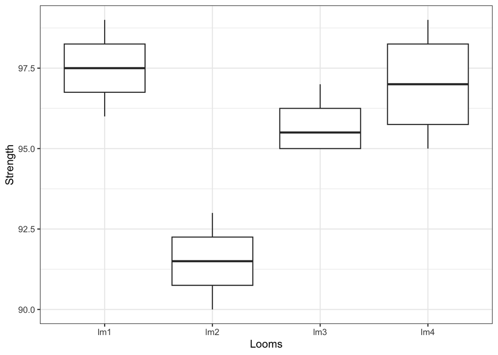

```r
strength=c(98,97,99,96,91,90,93,92,96,95,97,95,95,96,99,98)
looms=gl(n = 4, k = 4, labels = c("lm1","lm2","lm3","lm4"))

strength_loom = tibble(strength,looms)

strength_loom %>%
  ggplot(aes(x=looms,y=strength)) +
  geom_boxplot()+
  theme_bw()+
  labs(x="Looms",
       y="Strength")
```

#### ANOVA - To test the variance component hypothesis

```r
# to calculate the mean squares
aRE=aov(strength ~ looms, data = strength_loom)
summary(aRE)
```

```
            Df Sum Sq Mean Sq F value   Pr(>F)
looms        3  89.19  29.729   15.68 0.000188 ***
Residuals   12  22.75   1.896
---
Signif. codes:  0 '***' 0.001 '**' 0.01 '*' 0.05 '.' 0.1 ' ' 1
```

```r
confint(aRE)
```

```
                2.5 %     97.5 %
(Intercept) 96.000004 98.9999957
loomslm2    -8.121314 -3.8786858
loomslm3    -3.871314  0.3713142
loomslm4    -2.621314  1.6213142
```

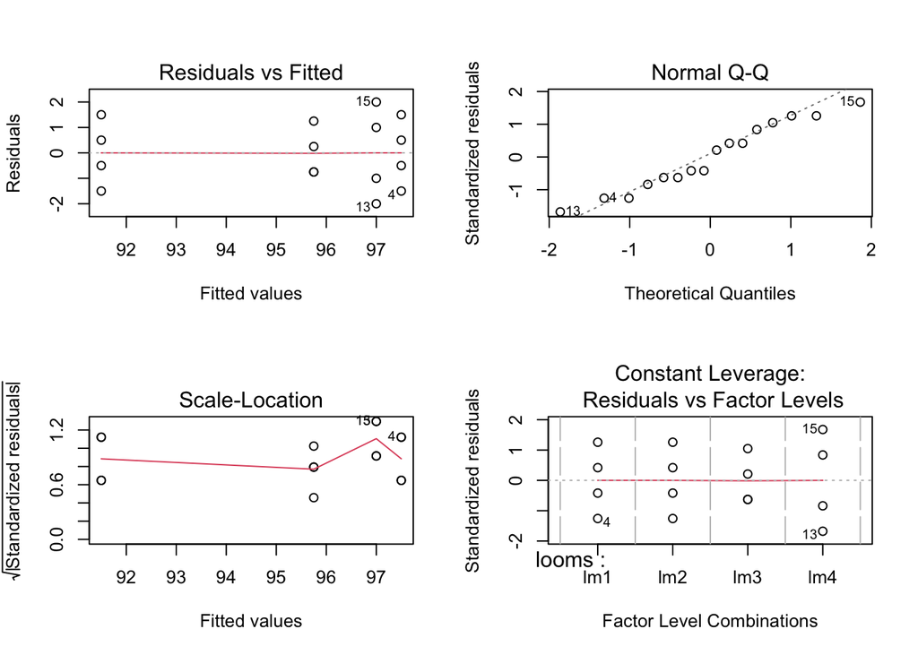

```r
par(mfrow=c(2,2))
plot(aRE)
```

The results from ANOVA indicates significant difference in the variability due to in the looms. We want to estimate variance components:

##### Moments Method

```r
# Estimate the variance components - method of moments
summary(aRE)
```

```
            Df Sum Sq Mean Sq F value   Pr(>F)
looms        3  89.19  29.729   15.68 0.000188 ***
Residuals   12  22.75   1.896
---
Signif. codes:  0 '***' 0.001 '**' 0.01 '*' 0.05 '.' 0.1 ' ' 1
```

```r
s2= 1.9
s2tau= (29.729 - 1.896)/4
s2y = s2 + s2tau
ICC = s2tau/s2y
```

##### MLE method

```r
library(lme4)
# Fit the Random Effect One-way ANOVA
anovaRE <- lmer(strength ~ 1 + (1 | looms))
summary(anovaRE)
```

```
Linear mixed model fit by REML ['lmerMod']
Formula: strength ~ 1 + (1 | looms)

REML criterion at convergence: 63.2

Scaled residuals:
     Min       1Q   Median       3Q      Max
-1.38018 -0.57260 -0.04342  0.82574  1.52491

Random effects:
 Groups   Name        Variance Std.Dev.
 looms    (Intercept) 6.958    2.638
 Residual             1.896    1.377
Number of obs: 16, groups:  looms, 4

Fixed effects:
            Estimate Std. Error t value
(Intercept)   95.438      1.363   70.01
```

```r
# Confidence Intervals Variance Components and Overall Mean
confint(anovaRE,oldNames=FALSE)
```

```
                          2.5 %    97.5 %
sd_(Intercept)|looms  1.1293759  5.748927
sigma                 0.9672533  2.184005
(Intercept)          92.4393299 98.435668
```

```r
# Estimates the random effect tau_i
ranef(anovaRE)
```

```
$looms
    (Intercept)
lm1   1.9309741
lm2  -3.6864051
lm3   0.2925718
lm4   1.4628591

with conditional variances for "looms"
```

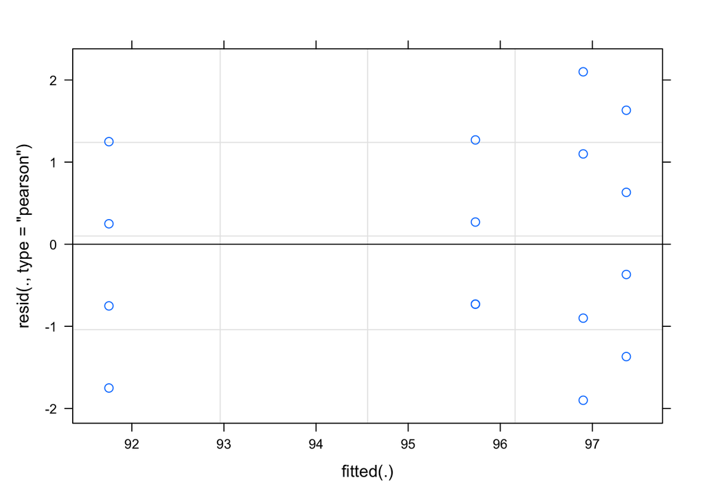

```r
# Check the residuals
par(mfrow = c(1, 2))
plot(anovaRE)
```

```r
#ICC
library(irr)
t(matrix(strength, nrow =  4))
```

```
     [,1] [,2] [,3] [,4]
[1,]   98   97   99   96
[2,]   91   90   93   92
[3,]   96   95   97   95
[4,]   95   96   99   98
```

```r
icc(t(matrix(strength, nrow =  4)))
```

```
 Single Score Intraclass Correlation

   Model: oneway
   Type : consistency

   Subjects = 4
     Raters = 4
     ICC(1) = 0.786

 F-Test, H0: r0 = 0 ; H1: r0 > 0
    F(3,12) = 15.7 , p = 0.000188

 95%-Confidence Interval for ICC Population Values:
  0.385 < ICC < 0.982
```

> The **conclusion**: The strength variability is significantly different from loom to loom (p <0.001). The variance component are:
> - The variance due to the looms is 6.958
> - The variance of the error: 1.896
> - The ICC is 0.786 (95% CI [0.39 to 0.98])

> We can conclude that the 78.6% of variability in the strength is due to the difference among the looms.

## Cardiovascular and Chocolate Study

The goal is to investigate the effect of consuming chocolate on cardiovascular health (Plasma Antioxidants from Chocolate, Nature, 2003). 3 types of chocolates:

- 100 g of dark chocolate : DC
- 100 g of dark chocolate with 200mL of full fat milk: DCMK
- 200 g of milk chocolate: MK

12 subjects. The total antioxidant capacity of their blood plasma was measured after 1 hour of consumption of one of the above level.

```r
DC    =c(118.8 ,    122.6 , 115.6 , 113.6 , 119.5 , 115.9 , 115.8 , 115.1 , 116.9 , 115.4 , 115.6 , 107.9)

DCMK  =c(105.4 ,    101.1 , 102.7 , 97.1,   101.9 ,98.9 ,   100.0,99.8,102.6,100.9,104.5,93.5)

MC    =c(102.1 ,    105.8 , 99.6  , 102.7 ,98.8 ,   100.9 , 102.8 ,98.7 ,94.7 ,97.8 ,99.7 ,98.6)

subjects = gl(n=12,k=1,length = 36,labels = (1:12))

cardio_chocolate = tibble(DC,DCMK,MC) %>%
  pivot_longer(cols = everything(),
               names_to = "group",
               values_to = "antioxidantCap") %>%
  mutate(subjects = gl(n=12,k=3,length = 36,labels = (1:12))
)
```

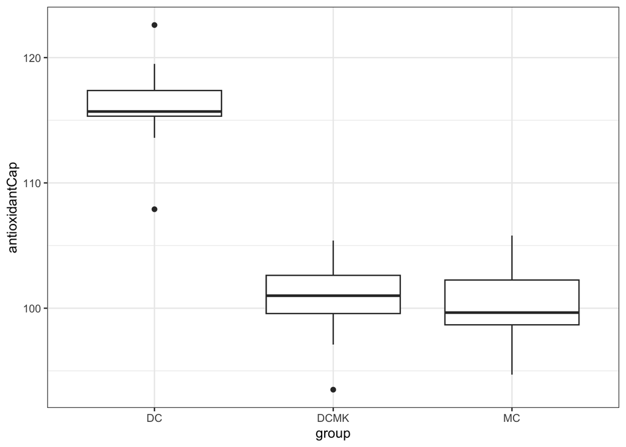

```r
cardio_chocolate %>%
  ggplot(aes(x=group,y=antioxidantCap))+
  geom_boxplot()+
  theme_bw()
```

```r
res = aov(antioxidantCap~group+subjects,data=cardio_chocolate)
summary(res)
```

```
            Df Sum Sq Mean Sq F value   Pr(>F)
group        2 1952.6   976.3 147.350 1.82e-13 ***
subjects    11  198.5    18.0   2.724   0.0218 *
Residuals   22  145.8     6.6
---
Signif. codes:  0 '***' 0.001 '**' 0.01 '*' 0.05 '.' 0.1 ' ' 1
```

```r
# variance components
library(lme4)
anovaRE <- lmer(antioxidantCap ~ group + (1 | subjects), data = cardio_chocolate)
summary(anovaRE)
```

```
Linear mixed model fit by REML ['lmerMod']
Formula: antioxidantCap ~ group + (1 | subjects)
   Data: cardio_chocolate

REML criterion at convergence: 174.5

Scaled residuals:
     Min       1Q   Median       3Q      Max
-1.90551 -0.46590 -0.04931  0.71717  1.51212

Random effects:
 Groups   Name        Variance Std.Dev.
 subjects (Intercept) 3.808    1.951
 Residual             6.626    2.574
Number of obs: 36, groups:  subjects, 12

Fixed effects:
            Estimate Std. Error t value
(Intercept) 116.0583     0.9324  124.47
groupDCMK   -15.3583     1.0509  -14.62
groupMC     -15.8750     1.0509  -15.11

Correlation of Fixed Effects:
          (Intr) grDCMK
groupDCMK -0.563
groupMC   -0.563  0.500
```

```r
# Confidence Intervals Variance Components and Overall Mean
confint(anovaRE,oldNames=FALSE)
```

```
                              2.5 %     97.5 %
sd_(Intercept)|subjects   0.4221091   3.448604
sigma                     1.9030082   3.367859
(Intercept)             114.2453133 117.871353
groupDCMK               -17.4119080 -13.304759
groupMC                 -17.9285746 -13.821425
```